# Grouped Histogram

## Requirements for this lab

In this lab, you are required to use the skills learned from Module 6 to create a grouped histogram using ggplot().

#### Please create a R Markdown file, set the output format as html_document. Finally knit the R Markdown file into the HTML file.

#### Please use the data provided to conduct a **Grouped Histogram** based on the step mentioned below.

- > Steps:
  > 1. Install and Load Required Packages.
  > 2. Load and Inspect the Dataset.
  > 3. Break the variable “CrimeRate” into three groups based on the range and create a new variable “RangeGroup”. You can use case_when() function.

  > > ```
  > > - Groups
  > >     * "CrimeRate < 250"
  > >     * "250 <= CrimeRate <= 500"
  > >     * "CrimeRate > 500"
  > >
  > > - Use case_when(): For example, we set height>200 or mass >200 is a group "large". And the "large" is a value in the new column "type". Similarly, we define the group "small" by setting height <= 200 and mass <= 200. We use a comma "," to separate different groups.\
  > > ```

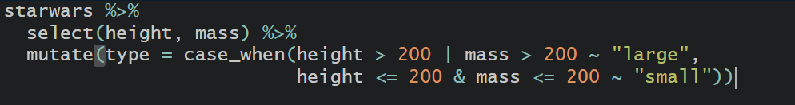

  > > Example for grouping using case_when().

  > 4. Create two color vectors. Here we just show you how to define the color vectors. The colors may not be perfect colors for the graphs.

  > > ```
  > > - col1=colorspace::diverge_hcl(n)
  > > - col2=c("green","blue","red")
  > > ```

  > 5. Plot a histogram of the variable “CrimateRate” and fill with the variable “Year”. Please use the first color vector col1 for this graph.
  > 6. Plot a histogram of the variable “CrimateRate” and fill with the variable “RangeGroup”, which you created in Step3. Please use second color vector col2 for this graph.

#### Color changes based on **“Year”**

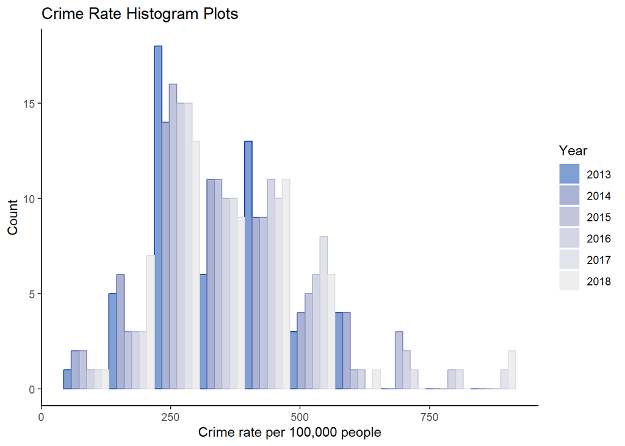

#### Color changes based on **Crime Rate Range Group**

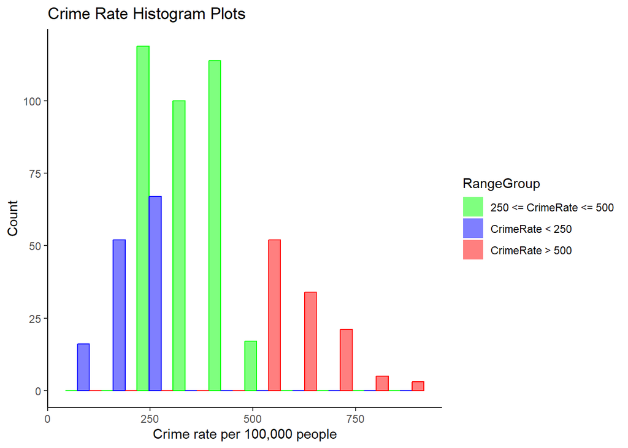